# Website Insights - Case Challenge 5

## Instructions

You are the growth analyst for an e-commerce site. The company CEO isn’t very happy with the volume of sales and, especially, of sales coming from new users. Therefore, she asked you to investigate whether there is something wrong in the conversion funnel or, in general, if you could suggest how conversion rate can be improved.

[Dataset](https://www.kaggle.com/aerodinamicc/ecommerce-website-funnel-analysis)

```r
#Load packages
install.packages("psych") # for describe function
install.packages("lubridate") # for date function
install.packages("ggrepel") # for graphic visualization

# Load packages
library("psych")
library("lubridate")
library("ggrepel")
library("tidyverse")

# lapply(c("tidyverse", "ISLR", "sjPlot", "ggcorrplot", "corrplot", "glmnet", "caret", "ROCR"), require, character.only = TRUE)

##### Data import ######
user_table_data = read_csv("user_table.csv")
home_page_table_data = read_csv("home_page_table.csv")
search_page_table_data = read_csv("search_page_table.csv")
payment_page_table_data = read_csv("payment_page_table.csv")
payment_confirmation_table_data = read_csv("payment_confirmation_table.csv")
```

## Check for duplicate records

```r
user_table_data[duplicated(user_table_data$user_id),] # no duplicate record
```

There is no duplicate record

```r
length(unique(user_table_data$user_id)) #90400 unique users

length(unique(home_page_table_data$user_id)) # 90400 unique users
```

As from the above, there were 90400 unique users in user table and 90400 unique users landed on the home page. This dataset only contains one-time users. It seems that the e-commerce site is not very effective for retaining users.

There are two features about our users: Device and Gender

```r
# Device
# The total number number of Desktop vs. Mobile users
user_table_data %>%
  select(device) %>%
  table()
```

```
.
Desktop  Mobile
  60200   30200
```

```r
# Since they are only one-time users with unique record, they are either desktop users or mobile users.
prop.table(table(user_table_data$device)) #imbalanced dataset with desktop vs Mobile = 0.67:0.33
```

```
  Desktop    Mobile
0.6659292 0.3340708
```

It’s an imbalanced dataset with desktop vs Mobile users = 0.67:0.33

```r
# Gender
# The total number number of Female vs. male users
user_table_data %>%
  select(sex) %>%
  table()
```

```
.
Female   Male
 45075  45325
```

```r
# Proportion of Female and male users
prop.table(table(user_table_data$sex))
```

```
   Female      Male
0.4986173 0.5013827
```

It’s a balanced dataset with Female VS Male users = 0.5: 0.5

## Time period for the dataset

```r
# Retrieve the data period
range(funnel$date)  # "2015-01-01"  to "2015-04-30"
```

Time: From 2015-01-01 to 2015-04-30

## Data manipulation

```r
# Create a user journey record
funnel <- user_table_data %>%
  left_join(home_page_table_data, by = "user_id") %>%
  left_join(search_page_table_data, by = "user_id") %>%
  left_join(payment_page_table_data, by = "user_id") %>%
  left_join(payment_confirmation_table_data, by = "user_id")

#rename the funnel table's column
page_name <-c("home_page", "search_page", "payment_page", "payment_confirmation_page")
colnames(funnel)[5:8] <- page_name

##### Funnel analysis by Device ######
# mutate() adds new variables and preserves existing ones;
melt_funnel_table <- funnel %>%
  mutate(home_page = ifelse(!is.na(home_page), TRUE, FALSE),
         search_page = ifelse(!is.na(search_page), TRUE, FALSE),
         payment_page = ifelse(!is.na(payment_page), TRUE, FALSE),
         payment_confirmation_page = ifelse(!is.na(payment_confirmation_page), TRUE, FALSE),
         year = year(date),
         month = month(date),
         day = day(date)
  ) %>%
  melt(measure.vars = c("home_page", "search_page", "payment_page", "payment_confirmation_page"),
               variable.name = "page", value.name = "visited")

#### Total visit count per month per device
page_visted_count <- melt_funnel_table %>%
  filter(visited == TRUE & page == "home_page") %>%
  group_by(device, month) %>%
  summarise(page_visit_total_count = n()) # summarise() creates a new data frame
### Create a stage table with monthly visit and page visit total count by month ######
page_visted_stage_table <- melt_funnel_table %>%
  filter(visited == TRUE) %>%
  group_by(device, year, month, page) %>%
  summarise(monthly_visits = n()) %>%
  left_join(page_visted_count, by = c("device", "month"))
```

## Plot for funnel performance over time by Device

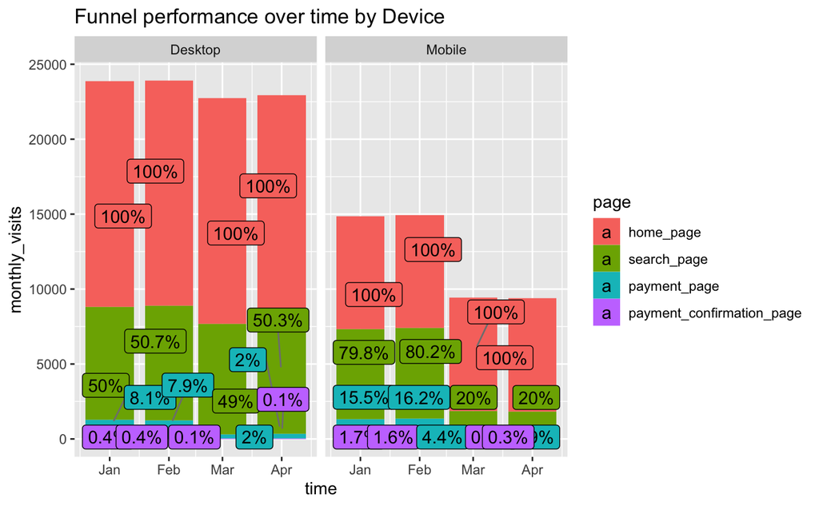

```r
##### Create a plot for funnel performance over time per device ######
melt_funnel_table %>%
  filter(visited == TRUE) %>%
  group_by(year, month, page, device) %>%
  summarise(monthly_visits = n()) %>%
  left_join(page_visted_count, by = c("device", "month")) %>%
  mutate(time = dmy(paste0("01/", month, "/", year)),
         percentage = round(monthly_visits/page_visit_total_count * 100, 1)) %>%
  ggplot(aes(x = time, y = monthly_visits, fill = page)) +
  geom_bar(stat = "identity") +
  geom_label_repel(aes(label = paste0(percentage, "%")), position = position_stack(vjust = 0.5), size = 4,
                   box.padding   = 0.35,
                   point.padding = 0.5,
                   segment.color = 'grey50') +
  facet_wrap(~device) +
  labs(title = "Funnel performance over time by Device")
```

The annotation is not placed at the right position since we have modified the date on x-axis. Let’s fix it for better visualization and use non-stacked barchart instead.

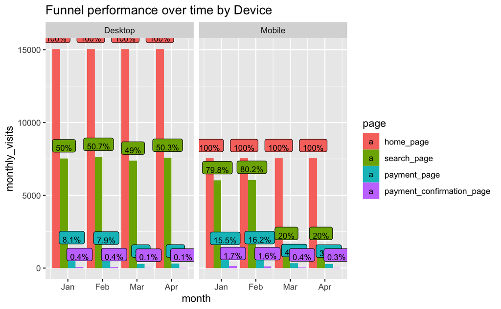

```r
##### Alternative: Fixed the x-axis label problem #####
melt_funnel_table %>%
  filter(visited == TRUE) %>%
  group_by(year, month, page, device) %>%
  summarise(monthly_visits = n()) %>%
  left_join(page_visted_count, by = c("device", "month")) %>%
  mutate(time = dmy(paste0("01/", month, "/", year)),
         percentage = round(monthly_visits/page_visit_total_count * 100, 1)) %>%
  ggplot(aes(x = month, y = monthly_visits, fill = page)) +
  geom_bar(stat = "identity", position = position_dodge()) +
  scale_x_continuous(labels = c("Jan","Feb","Mar","Apr"), breaks = 1:4) +
  geom_label(aes(label = paste0(percentage, "%")), size = 3, vjust = -0.5, position = position_dodge(0.9)) +
  facet_wrap(~device) +
  #coord_flip() +
  labs(title = "Funnel performance over time by Device")
```

Let’s look into the funnel performance on each device

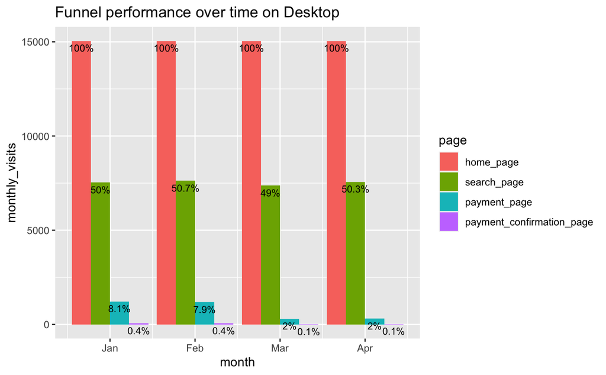

```r
### Desktop only plot #####
melt_funnel_table %>%
  filter(visited == TRUE & device == "Desktop") %>%
  group_by(device, year, month, page) %>%
  summarise(monthly_visits = n()) %>%
  left_join(page_visted_count, by = c("device", "month")) %>%
  mutate(time = dmy(paste0("01/", month, "/", year)),
         percentage = round(monthly_visits/page_visit_total_count * 100, 1)) %>%
  ggplot(aes(x = month, y = monthly_visits, fill = page)) + # forcats::fct_rev()
  geom_col(position = "dodge") +
  scale_x_continuous(labels = c("Jan","Feb","Mar","Apr"), breaks = 1:4) + # modify the date format on x-Axis
  geom_text(aes(label = paste0(percentage, "%")), size = 3, vjust = 1.5, position = position_dodge(0.9)) +
  #coord_flip() +
  labs(title = "Funnel performance over time on Desktop")  # vjust = -0.25, hjust = 1.2
```

```r
# 0 means left-justified
# 1 means right-justified
# Vertical adjustment for geoms that have a position (like points or lines),
# not a dimension (like bars or areas). Set to 0 to align with the bottom,
# 0.5 for the middle, and 1 (the default) for the top.
```

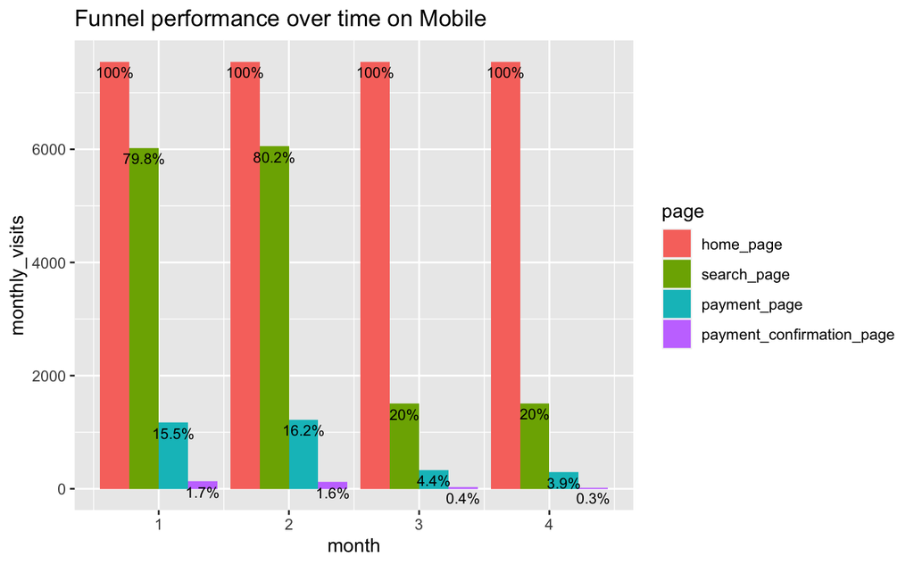

```r
### Mobile only plot #####
melt_funnel_table %>%
  filter(visited == TRUE & device == "Mobile") %>%
  group_by(device, year, month, page) %>%
  summarise(monthly_visits = n()) %>%
  left_join(page_visted_count, by = c("device", "month")) %>%
  mutate(time = dmy(paste0("01/", month, "/", year)),
         percentage = round(monthly_visits/page_visit_total_count * 100, 1)) %>%
  ggplot(aes(x = month, y = monthly_visits, fill = page)) + # forcats::fct_rev()
  geom_col(position = "dodge") +
  geom_text(aes(label = paste0(percentage, "%")), size = 3, vjust = 1.5, position = position_dodge(0.9)) +
  #coord_flip() +
  labs(title = "Funnel performance over time on Mobile")
```

## Insight 1

Overall, the mobile version of the e-commerce site had better conversion rates than the Desktop version

As for mobile version, the Home-to-Search-to-Payment-to-Confirmation page was more or less the same from Jan to Feb, but the conversion from Home-to-Search page drops dramatically to 20% (80.2% in previous month) starting from March which in turn lowered the conversion from Search-to-Payment-to-Confirmation page. Why? Am I attracting the right type of user to my site to begin with?

As for Desktop version, the Home-to-Search page remained very stable over time, but the search-to-payment conversion dropped significantly from 49% to 2% (from 50.7% to 7.9% in previous month). Is there a bug or UI issue in the Search process that’s preventing users from finding the right products?

## Funnel analysis by Gender

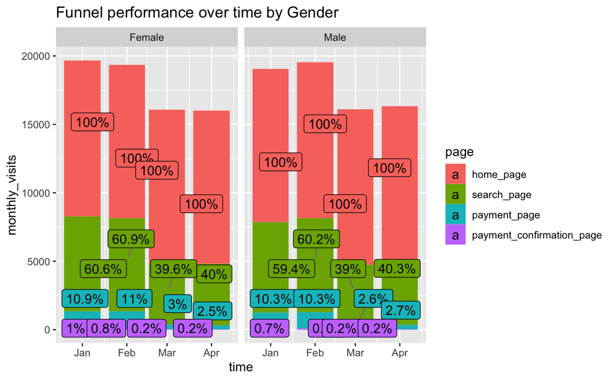

```r
#### Total visit count per month per device
page_visted_count_group_by_gender <- melt_funnel_table %>%
  filter(visited == TRUE & page == "home_page") %>%
  group_by(sex, month) %>%
  summarise(page_visit_total_count = n()) # summarise() creates a new data frame
### Create a stage table with monthly visit and page visit total count by month ######
page_visted_stage_table_group_by_gender <- melt_funnel_table %>%
  filter(visited == TRUE) %>%
  group_by(sex, year, month, page) %>%
  summarise(monthly_visits = n()) %>%
  left_join(page_visted_count_group_by_gender, by = c("sex", "month"))
##### Create a plot for funnel performance over time per device ######
melt_funnel_table %>%
  filter(visited == TRUE) %>%
  group_by(year, month, page, sex) %>%
  summarise(monthly_visits = n()) %>%
  left_join(page_visted_count_group_by_gender, by = c("sex", "month")) %>%
  mutate(time = dmy(paste0("01/", month, "/", year)),
         percentage = round(monthly_visits/page_visit_total_count * 100, 1)) %>%
  ggplot(aes(x = time, y = monthly_visits, fill = page)) +
  geom_bar(stat = "identity") +
  geom_label_repel(aes(label = paste0(percentage, "%")), position = position_stack(vjust = 0.5), size = 4,
                   box.padding   = 0.35,
                   point.padding = 0.5,
                   segment.color = 'grey50') +
  facet_wrap(~sex) +
  labs(title = "Funnel performance over time by Gender")
```

## Insight 2

There is no significant difference between Female and Male customers regarding the user journey. So, we can rule out the gender related problem